# Data-Driven Segmentation of U.S. Colleges and Universities Using K-Means Clustering on IPEDS Data

Author

Benjamin Minor

Published

December 9, 2025

Slides: slides.html (Go to `slides.qmd` to edit.)

## Introduction

Clustering is a central technique in unsupervised machine learning, used to reveal natural groupings within complex datasets where class labels are unknown. Among its methods, K-Means clustering remains widely applied for its simplicity, scalability, and interpretability (Mohd Talib, Abd Majid, and Sahran 2023). The algorithm partitions data into (k) groups based on similarity, minimizing within-cluster variance while increasing separation between clusters. This structure is valuable when the goal is understanding rather than prediction, such as comparing institutions by quantitative indicators of performance, resources, and access.

In higher education research, cluster analysis has long been used to explore structural and performance diversity across institutions (Huberty, Jordan, and Brandt 2005). This approach makes it possible to move beyond broad categorical labels and examine measurable dimensions such as outcomes, funding, and enrollment scale. A two-stage framework that combines factor analysis with clustering has also been proposed to derive empirically grounded institutional types (Elam 2016).

Standardized data and documentation have increased the reliability of these methods (National Center for Education Statistics 2023). Best practices for merging and cleaning educational datasets emphasize reproducibility and schema consistency in large-scale analysis (Kelchen 2019). Together, these sources point to the value of structured, data-driven methods in institutional research. The Integrated Postsecondary Education Data System (IPEDS), maintained by the National Center for Education Statistics, provides the standardized foundation for this type of large-scale institutional analysis. IPEDS collects consistent and comparable data on U.S. colleges and universities, making it a central source for empirical studies that analyze institutional differences through quantitative modeling.

Hybrid models further advance peer identification by pairing quantitative clustering with expert validation, improving interpretability and practical use (Texas Association for Institutional Research 2022). This balance between algorithmic structure and contextual review supports robust benchmarking and decision-making.

The present study applies K-Means clustering to IPEDS data to identify data-driven groupings of postsecondary institutions based on financial, academic, and outcome indicators. The objective is to uncover underlying institutional profiles that describe how U.S. colleges and universities align or differ in measurable ways, offering a transparent and scalable framework for understanding institutional diversity (Huberty, Jordan, and Brandt 2005; National Center for Education Statistics 2023; Elam 2016).

## Literature Review

**Source Summaries (click to expand)**

**Proposal of a New Method to Classify Higher Education Institutions**  
[PDF Link – Otterbein University Digital Commons](https://digitalcommons.otterbein.edu/cgi/viewcontent.cgi?article=1031&context=stu_dist)  
Elam (2016) lays out a two step setup that mixes factor analysis with cluster analysis to build a cleaner, data driven way to sort colleges. The study pulls academic, financial, and demographic variables and lets the clusters form from what the numbers actually show. The results give a more grounded picture of institutional differences than the usual labels ever do.

**Cluster Analysis of Multivariate Data: Efficiency Versus Interpretability of Classifications**  
[PDF Link – Biometrics](https://doi.org/10.2307/2528559)  
Forgy (1965) is one of the earliest pieces that explains how to run clustering in multivariate settings, including what later got called the Forgy initialization for K Means. The paper talks through the balance between squeezing out statistical efficiency and keeping the results readable. A lot of the choices in this project about how clusters are initialized and evaluated trace back to this foundation.

**Cluster Analysis in Higher Education Research**  
[PDF Link – Springer](https://link.springer.com/content/pdf/10.1007/1-4020-3279-X_8.pdf)  
Huberty, Jordan, and Brandt (2005) show how cluster analysis has been used to study diversity and performance patterns across colleges. They point out that clustering can reveal similarities and gaps that the standard categories hide, especially when you stack financial and outcome data together. They also go over variable choice, scaling, and validation, which feeds directly into the structure of this capstone.

**Data Clustering: 50 Years Beyond K Means**  
[PDF Link – Pattern Recognition Letters](https://doi.org/10.1016/j.patrec.2009.09.011)  
Jain (2010) looks back over five decades of clustering research. K Means is the anchor point, but the paper compares it to other algorithms and distance choices. It highlights what works about K Means, like its speed and clarity, and also where it struggles, like odd shaped clusters and sensitivity to initialization. This context supports using K Means here while being honest about its limits with institutional data.

**Merging Data to Facilitate Analyses**  
[PDF Link – Robert Kelchen](https://robertkelchen.com/wp-content/uploads/2019/11/kelchen_merging_original.pdf)  
Kelchen (2019) gives a straightforward walkthrough on how to merge and clean education datasets like IPEDS and federal aid files. It shows the usual pain points like mismatched schemas, missing data, duplicate identifiers, and messy labels, and lays out practices for making the work reproducible. This capstone follows that framework in how IPEDS files are merged on UNITID, how measures like revenue per FTE are built, and how missing data is handled.

**Least Squares Quantization in PCM**  
[PDF Link – IEEE Transactions on Information Theory](https://doi.org/10.1109/TIT.1982.1056489)  
Lloyd (1982) formalizes what became the Lloyd algorithm for K Means, framing it as a least squares quantization problem. It explains the iterative assignment and update steps and shows that the objective will always drop even though the algorithm can land in local minima. This gives the mathematical backbone for the K Means run in this project and backs the choice to use multiple random starts.

**Identification of Student Behavioral Patterns in Higher Education Using K Means Clustering and Support Vector Machine**  
[PDF Link – MDPI Applied Sciences](https://www.mdpi.com/2076-3417/13/5/3267)  
Mohd Talib et al. (2023) use K Means to group student behavior and performance patterns, then bring in a Support Vector Machine to check how stable the clusters are. They show that normalized features and careful validation can uncover meaningful student behavior groups that instructors can actually use. It backs the idea that unsupervised clustering can simplify complex education data into readable segments.

**Institutional Groupings in IPEDS: Considerations for Data Use**  
[Web Link – NCES](https://nces.ed.gov/ipeds/use-the-data/institutional-groupings-in-ipeds)  
NCES explains how IPEDS builds and documents sector, control, and other grouping variables. The guidance pushes for consistent definitions when comparing institutions across official groupings and custom peer sets. These points shape how this capstone uses sector labels, aligned finance fields, and clear documentation when building the analytic file.

**A Hybrid Approach to Identifying National Peer Institutions**  
[PDF Link – Texas Association for Institutional Research](https://www.texas-air.org/wp-content/uploads/2022/03/E3-A-Hybrid-Approach-to-Identifying-National-Peer-Institutions.pdf)  
The TAIR report shows a hybrid method that starts with statistical clustering and then layers in expert judgment. The initial clusters come from performance and enrollment data, then reviewers adjust the groups to make them more useful in practice. It reinforces that cluster results work best as a starting point for peer benchmarking rather than a locked in classification.

## Methods

This study applies the **K-Means clustering algorithm** to group U.S. higher education institutions into data-driven segments based on scale, resources, access, and outcomes. The process follows the standard Lloyd–Forgy heuristic for iterative centroid-based optimization, as described in the literature on higher education clustering and institutional classification (Lloyd 1982).

## Objective and Notation

Let $X \in \mathbb{R}^{n \times d}$ be the standardized feature matrix, where each row represents an institution and each column represents a numeric feature such as revenue per FTE, tuition, or completion rate. The goal of K Means is to partition $n$ observations into $k$ clusters $C = \{C_1, C_2, \ldots, C_k\}$ and to estimate centroids $\mu_1, \mu_2, \ldots, \mu_k$ that minimize the within cluster sum of squares (WCSS):

$$\min_{C} \sum_{i=1}^{k} \sum_{x_j \in C_i} \lVert x_j - \mu_i \rVert^2$$

For a fixed cluster assignment, the centroid for cluster $i$ is the mean of the observations in $C_i$:

$$\mu_i = \frac{1}{|C_i|} \sum_{x_j \in C_i} x_j$$

### Lloyd’s Algorithm (Assignment and Update)

The algorithm alternates between two phases until it converges:

1. **Assignment step**
   Each observation is assigned to the nearest cluster centroid based on Euclidean distance:
   $$C_i^{(t)} = \{x_j : \|x_j - \mu_i^{(t)}\|^2 \leq \|x_j - \mu_r^{(t)}\|^2,\ \forall r \in \{1, \ldots, k\}\}$$
2. **Update step**
   After assignments, centroids are updated to reflect the mean of their current members:
   $$\mu_i^{(t+1)} = \frac{1}{|C_i^{(t)}|} \sum_{x_j \in C_i^{(t)}} x_j$$

The process repeats until there is minimal change in cluster assignments or centroid locations between iterations (Lloyd 1982).

### Feature Scaling and Preprocessing

Because IPEDS variables differ in magnitude and measurement units (for example, tuition in USD, completion rates as percentages, and revenue per FTE in dollars), all continuous numeric variables were standardized using **z-score normalization** prior to clustering (Lloyd 1982; Huberty, Jordan, and Brandt 2005):

$$z = \frac{x - \bar{x}}{s}$$

where ({x}) is the sample mean and (s) is the sample standard deviation. This ensures that each variable contributes on a comparable scale to the Euclidean distances used in K-Means clustering (Lloyd 1982).

Categorical fields, such as institutional control type, were not standardized. Instead, they were reserved for post-cluster interpretation and comparison.

### Implementation Procedure

K-Means was implemented using R’s base `stats::kmeans()` function with multiple random initializations (`nstart = 25`) to reduce sensitivity to initial centroid placement. To ensure reproducibility, all random seeds were fixed using `set.seed(2024)`.

Cluster inputs included:

- `REV_PER_FTE` (revenue per full-time equivalent)
- `INSTR_EXP_FTE` (instructional expenses per FTE)
- `TUITION1` (in-state undergraduate tuition)
- `OM8_PCT_COMP` (8-year completion rate)
- `RET_PCF` (retention rate, full-time; part-time as fallback)

The optimal number of clusters (k) was not pre-specified in this section. It is evaluated empirically in the **Modeling and Results** section using the Elbow method and Silhouette analysis, following (Huberty, Jordan, and Brandt 2005; Texas Association for Institutional Research 2022).

### Justification of Method

K-Means was selected for its interpretability and computational efficiency on medium-dimensional data. Prior studies in higher education analytics have shown that unsupervised clustering can reveal institutional typologies that traditional classifications overlook (Huberty, Jordan, and Brandt 2005; National Center for Education Statistics 2023; Mohd Talib, Abd Majid, and Sahran 2023; Elam 2016). This approach supports empirical grouping based on shared performance and resource characteristics, providing a basis for benchmarking and peer comparison (Kelchen 2019).

### Cluster Validation and Model Evaluation

To ensure that groupings derived from K-Means were both stable and interpretable, multiple internal validation techniques were applied. Because K-Means requires the number of clusters (k) to be specified in advance, choosing an appropriate (k) is a key step that affects both interpretability and robustness (Huberty, Jordan, and Brandt 2005; Texas Association for Institutional Research 2022).

#### Elbow Method (Within-Cluster Sum of Squares)

The Elbow method evaluates the total within-cluster sum of squares (WCSS) across a range of (k) values:

$$WCSS(k) = \min_C \sum_{i=1}^{k} \sum_{x_j \in C_i} \|x_j - \mu_i\|^2$$

As (k) increases, WCSS decreases because cluster radii shrink. The optimal (k) is typically chosen at the “elbow” point: the inflection where additional clusters yield diminishing reductions in WCSS. This heuristic balances compact clusters with a parsimonious number of groups.

#### Silhouette Analysis

Silhouette analysis was used to complement the Elbow approach and assess how well each institution fits within its assigned cluster compared to neighboring clusters (Mohd Talib, Abd Majid, and Sahran 2023). The Silhouette coefficient for observation (i) is

$$s(i) = \frac{b(i) - a(i)}{\max[a(i), b(i)]}$$

where

- (a(i)) is the average distance between (i) and all other points in its cluster (cohesion),
- (b(i)) is the minimum average distance between (i) and points in the nearest neighboring cluster (separation).

Values range from (-1) to (1), with higher scores indicating better separation and cohesion. The average Silhouette width was computed across all institutions for each candidate (k), and the value of (k) with the highest mean silhouette was treated as the most stable partition.

#### Model Stability and Reproducibility

To reduce randomness from centroid initialization, the clustering routine was run with multiple random starts (`nstart = 25`) and a fixed seed (`set.seed(2024)`), following best practices for reproducible analysis (Kelchen 2019). This helps ensure that the resulting segmentation is not an artifact of a single random state.

#### Summary

This validation framework combines geometric compactness (Elbow method) and structural separation (Silhouette coefficient) to justify the final number of clusters. The choice of (k) and the interpretation of the resulting segments are presented in the following sections.

## Exploratory Data Analysis

### Data Exploration and Visualization

#### Dataset Overview

This study uses institutional-level data from the **Integrated Postsecondary Education Data System (IPEDS)** for the 2023 collection year (2023–2024 cycle). IPEDS collects standardized information from all U.S. postsecondary institutions that participate in federal financial aid programs, covering the public, private nonprofit, and private for-profit sectors.

The following survey components were used and merged on the key `UNITID`:

- **HD2023** — Institutional characteristics (name, control, sector, etc.)
- **F2223_F1A** — Finance (public, GASB)
- **F2223_F2** — Finance (private nonprofit, FASB)
- **F2223_F3** — Finance (private for-profit)
- **EFIA2023** — 12-month instructional activity (source of FTE)
- **ADM2023** — Admissions (admission rate, tuition; used selectively)
- **OM2023** — Outcome measures (completion/attainment; used selectively)

All files were downloaded from the NCES IPEDS Data Center.

#### Variable Selection and Preparation

To represent institutional scale, financial capacity, access, and outcomes, variables were drawn from multiple components and aligned by `UNITID`. The main fields used are summarized below:

| Feature Group | Variable (Field) | Description |
| --- | --- | --- |
| **Institutional Scale** | `FTE_TOTAL` (built from EFIA2023) | Total full-time-equivalent enrollment (UG + Grad + DPP if present). |
| **Financial Resources** | `TOT_REV` (F1D01 / F2D162 / F3D12) | Total revenues (public), total revenues and investment return (nonprofit/for-profit). |
|  | `INSTR_EXP` (F1C011 / F2E011 / F3E011) | Instructional expenses (aligned across control types). |
|  | `TOT_EXP` (F1N07 / F2B02 / F3B02) | Total operating expenses. |
| **Access and Price** | `ADM_RATE`, `TUITION1` (ADM2023 / IC2023) | Admission rate; in-state tuition and fees. |
| **Outcomes** | `OM8_PCT_COMP` (OM2023 or derived) | 8-year outcome/completion measure. |

Where variables differed by control type, fields were harmonized to shared names (for example, `TOT_REV`, `INSTR_EXP`, `TOT_EXP`). Ratios per FTE were computed after merging FTE data.

#### Data Cleaning and Integration

Finance data from public (`F1A`), private nonprofit (`F2`), and private for-profit (`F3`) files were imported and mapped to total revenue, instructional expense, and total expense. Twelve-month instructional activity (`EFIA2023`) provided undergraduate, graduate, and total FTE values; reported FTE were preferred, with estimated values as fallback. Monetary values are reported in nominal USD for 2023–24 and are not inflation-adjusted.

```r
# ----libraries-------------------------------------------------------------
library(tidyverse)   # data wrangling / joins / ggplot2
library(janitor)     # clean column names
library(gt)          # summary tables
library(scales)      # formatting helpers
library(GGally)      # quick pair plots (optional)
library(corrr)       # correlation summaries (optional)
library(here)        # reproducible relative paths
library(patchwork)   # plot layouts (optional)

# ----paths-----------------------------------------------------------------
data_dir <- here("data")  # change if your files live elsewhere

# ----helper: robust numeric coercion--------------------------------------
numify <- function(x) as.numeric(gsub("[^0-9.\\-]", "", as.character(x)))

# ----load core IPEDS components-------------------------------------------
hd  <- read_csv(file.path(data_dir, "HD2023.csv"))   |> clean_names()
adm <- read_csv(file.path(data_dir, "ADM2023.csv"))  |> clean_names()
om  <- read_csv(file.path(data_dir, "OM2023.csv"))   |> clean_names()

# Finance (public / private nonprofit / private for-profit)
f1a <- read_csv(file.path(data_dir, "F2223_F1A.csv")) |> clean_names()
f2  <- read_csv(file.path(data_dir, "F2223_F2.csv"))  |> clean_names()
f3  <- read_csv(file.path(data_dir, "F2223_F3.csv"))  |> clean_names()

# 12-month instructional activity (FTE source)
efia <- read_csv(
  file.path(data_dir, "EFIA2023.csv"),
  na = c("", ".", "-", "—", "NA", "N/A")
) |> clean_names()

# Student charges (tuition and fees)
ic_ay <- read_csv(file.path(data_dir, "IC2023.csv"))  |> clean_names()

# Student financial aid (Pell Grant %)
sfa <- read_csv(file.path(data_dir, "SFA2223.csv"))   |> clean_names()

# Fall retention & student-faculty ratio
ef2023d <- read_csv(file.path(data_dir, "EF2023D.csv")) |> clean_names()

# ----EFIA -> FTE totals (coerce safely)-----------------------------------
efia <- efia |>
  mutate(across(any_of(c("fteug","efteug","ftegd","eftegd","ftedpp")), numify))

efia_fte <- efia |>
  transmute(
    unitid,
    fte_ug    = coalesce(fteug,  efteug),
    fte_grad  = coalesce(ftegd,  eftegd),
    fte_dpp   = ftedpp,
    fte_total = coalesce(fteug,  efteug, 0) +
                coalesce(ftegd,  eftegd, 0) +
                coalesce(ftedpp, 0)
  )

# ----finance: align to common names & coerce numeric-----------------------
f1a_fin <- f1a |>
  mutate(across(any_of(c("f1d01","f1c011","f1n07")), numify)) |>
  transmute(
    unitid,
    tot_rev   = f1d01,
    instr_exp = f1c011,
    tot_exp   = f1n07,
    control   = "Public"
  )

f2_fin <- f2 |>
  mutate(across(any_of(c("f2d162","f2e011","f2b02")), numify)) |>
  transmute(
    unitid,
    tot_rev   = f2d162,
    instr_exp = f2e011,
    tot_exp   = f2b02,
    control   = "Private Nonprofit"
  )

f3_fin <- f3 |>
  mutate(across(any_of(c("f3d12","f3e011","f3b02")), numify)) |>
  transmute(
    unitid,
    tot_rev   = f3d12,
    instr_exp = f3e011,
    tot_exp   = f3b02,
    control   = "Private For-Profit"
  )

fin <- bind_rows(f1a_fin, f2_fin, f3_fin)

# ----unified sector handling-----------------------------------------------
fin <- fin |>
  mutate(sector_fin = control) |>
  select(-control)

if ("control" %in% names(hd)) {
  hd <- hd |>
    mutate(
      sector_hd = dplyr::case_match(
        control,
        1 ~ "Public",
        2 ~ "Private Nonprofit",
        3 ~ "Private For-Profit",
        .default = NA_character_
      )
    )
} else {
  hd <- hd |> mutate(sector_hd = NA_character_)
}

# ----tuition, Pell, retention, stufacr (robust numeric)-------------------
ic_sel <- ic_ay |>
  mutate(across(any_of(c("tuition1")), numify)) |>
  transmute(unitid, tuition1)

sfa_sel <- sfa |>
  mutate(across(any_of(c("pgrnt_p")), numify)) |>
  transmute(unitid, pct_pell = pgrnt_p)

ef_ret <- ef2023d |>
  mutate(across(any_of(c("ret_pcf","ret_pcp","stufacr")), numify)) |>
  transmute(unitid, ret_pcf, ret_pcp, stufacr)

# ----merge all components (single clean 'sector')--------------------------
ipeds <- hd |>
  left_join(fin,      by = "unitid") |>
  left_join(efia_fte, by = "unitid") |>
  left_join(ic_sel,   by = "unitid") |>
  left_join(sfa_sel,  by = "unitid") |>
  left_join(ef_ret,   by = "unitid") |>
  left_join(adm,      by = "unitid") |>
  left_join(om,       by = "unitid") |>
  mutate(
    sector = dplyr::coalesce(sector_hd, sector_fin),
    sector = factor(
      sector,
      levels = c("Public", "Private Nonprofit", "Private For-Profit")
    )
  ) |>
  filter(!is.na(unitid), !is.na(fte_total), fte_total > 0) |>
  distinct(unitid, .keep_all = TRUE) |>
  mutate(
    rev_per_fte    = tot_rev   / fte_total,
    instr_exp_fte  = instr_exp / fte_total,
    exp_per_fte    = tot_exp   / fte_total,
    retention_rate = coalesce(ret_pcf, ret_pcp)
  )

# ----quick composition summary---------------------------------------------
ipeds |>
  summarise(
    total_institutions = n(),
    public_share       = mean(sector == "Public",             na.rm = TRUE),
    nonprofit_share    = mean(sector == "Private Nonprofit",  na.rm = TRUE),
    forprofit_share    = mean(sector == "Private For-Profit", na.rm = TRUE)
  ) |>
  gt() |>
  fmt_percent(columns = 2:4, decimals = 1)
```

| total_institutions | public_share | nonprofit_share | forprofit_share |
| --- | --- | --- | --- |
| 5959 | 32.2% | 30.3% | 37.6% |

```r
# ----prep for visuals / modeling------------------------------------------
if (!"om8_pct_comp" %in% names(ipeds)) {
  need <- c("omawdp8","omnoawd","omenrap","omenryp")
  if (all(need %in% names(ipeds))) {
    ipeds <- ipeds |>
      mutate(
        om_total     = omawdp8 + omnoawd + omenrap + omenryp,
        om8_pct_comp = if_else(om_total > 0, 100 * omawdp8 / om_total, NA_real_)
      )
  }
}

if ("tuition1" %in% names(ipeds) && !is.numeric(ipeds$tuition1)) {
  ipeds <- ipeds |>
    mutate(tuition1 = readr::parse_number(as.character(tuition1)))
}

vis_df <- ipeds |>
  filter(!is.na(sector),
         !is.na(tuition1),
         !is.na(rev_per_fte),
         !is.na(instr_exp_fte),
         !is.na(om8_pct_comp)) |>
  mutate(
    tuition_k = tuition1 / 1000,
    rev_fte_k = rev_per_fte / 1000,
    exp_fte_k = instr_exp_fte / 1000
  )
```

#### Figure 1. Distributions of Core Metrics

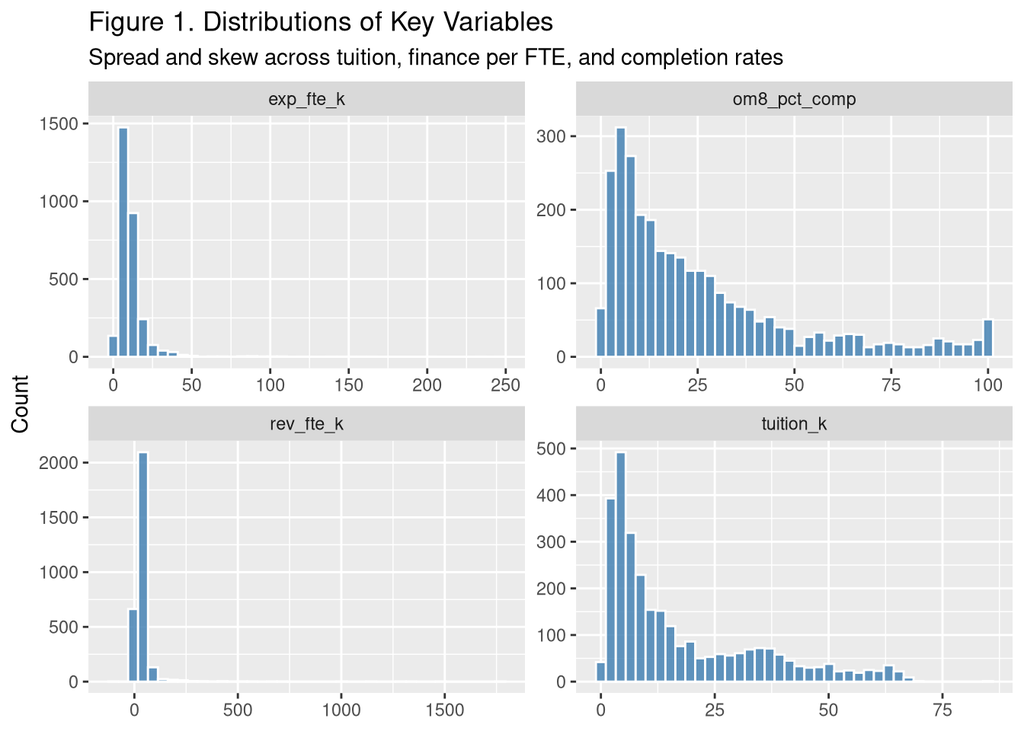

```r
# ----figure-1--------------------------------------------------------------
#| label: fig-dist
#| fig-cap: "Distributions of Key Variables"
vis_df |>
  mutate(
    tuition_k = tuition1 / 1000,
    rev_fte_k = rev_per_fte / 1000,
    exp_fte_k = instr_exp_fte / 1000
  ) |>
  select(tuition_k, rev_fte_k, exp_fte_k, om8_pct_comp) |>
  pivot_longer(everything(), names_to = "metric", values_to = "value") |>
  ggplot(aes(value)) +
  geom_histogram(bins = 40, fill = "#4682B4", color = "white", alpha = 0.85) +
  facet_wrap(~ metric, scales = "free", ncol = 2) +
  labs(
    title = "Figure 1. Distributions of Key Variables",
    subtitle = "Spread and skew across tuition, finance per FTE, and completion rates",
    x = NULL, y = "Count"
  )
```

#### Figure 2. Tuition vs Completion by Sector

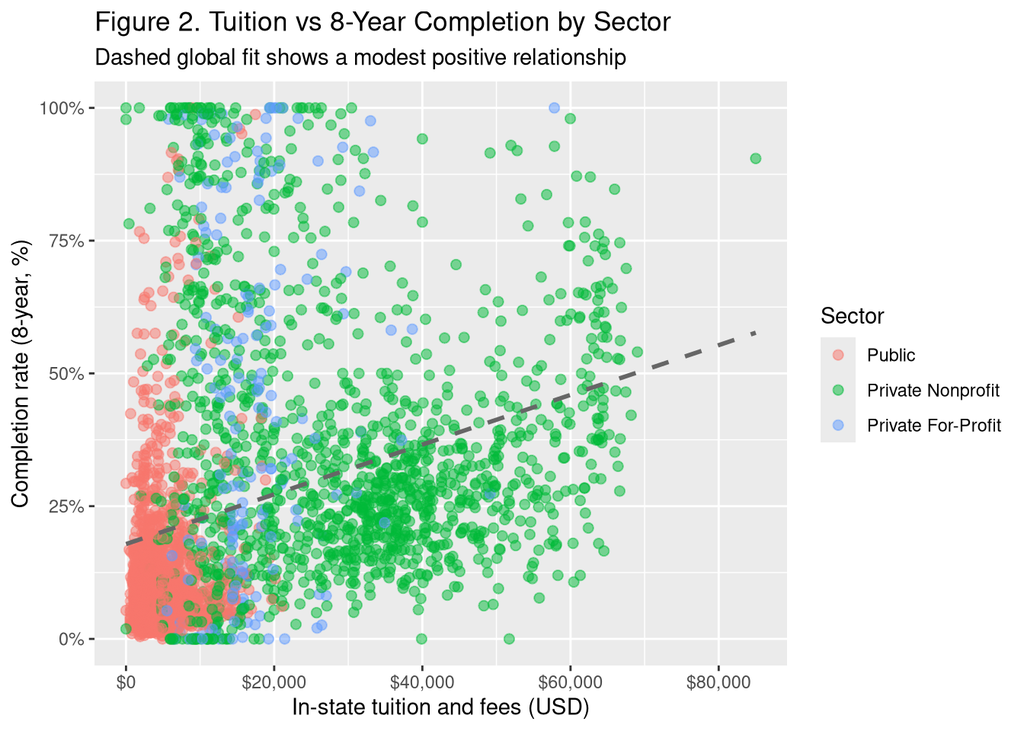

```r
#----figure-2--------------------------------------------------------------
#| label: fig-tuition-completion
#| fig-cap: "Tuition vs 8-Year Completion by Sector"
ggplot(vis_df, aes(tuition1, om8_pct_comp, color = sector)) +
  geom_point(alpha = 0.5, size = 2) +
  geom_smooth(method = "lm", se = FALSE, linetype = "dashed", color = "gray40") +
  scale_x_continuous(labels = dollar_format()) +
  scale_y_continuous(labels = label_percent(scale = 1)) +
  labs(
    title = "Figure 2. Tuition vs 8-Year Completion by Sector",
    subtitle = "Dashed global fit shows a modest positive relationship",
    x = "In-state tuition and fees (USD)",
    y = "Completion rate (8-year, %)",
    color = "Sector"
  )
```

#### Figure 3. Revenue vs Instructional Expense per FTE

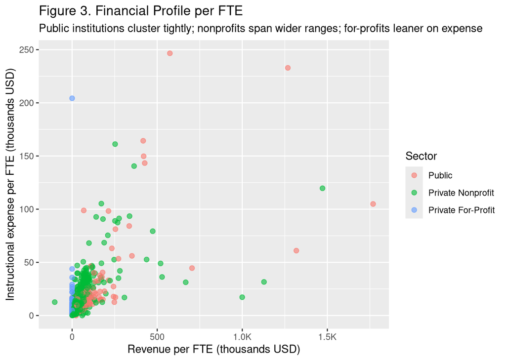

```r
#----figure-3--------------------------------------------------------------
#| label: fig-rev-exp-fte
#| fig-cap: "Financial Profile per FTE"
vis_df |>
  mutate(
    rev_fte_k = rev_per_fte / 1000,
    exp_fte_k = instr_exp_fte / 1000
  ) |>
  ggplot(aes(rev_fte_k, exp_fte_k, color = sector)) +
  geom_point(alpha = 0.6, size = 2) +
  scale_x_continuous(labels = label_number(scale_cut = cut_short_scale())) +
  scale_y_continuous(labels = label_number(scale_cut = cut_short_scale())) +
  labs(
    title = "Figure 3. Financial Profile per FTE",
    subtitle = "Public institutions cluster tightly; nonprofits span wider ranges; for-profits leaner on expense",
    x = "Revenue per FTE (thousands USD)",
    y = "Instructional expense per FTE (thousands USD)",
    color = "Sector"
  )
```

#### Figure 4. Correlation of Key Variables

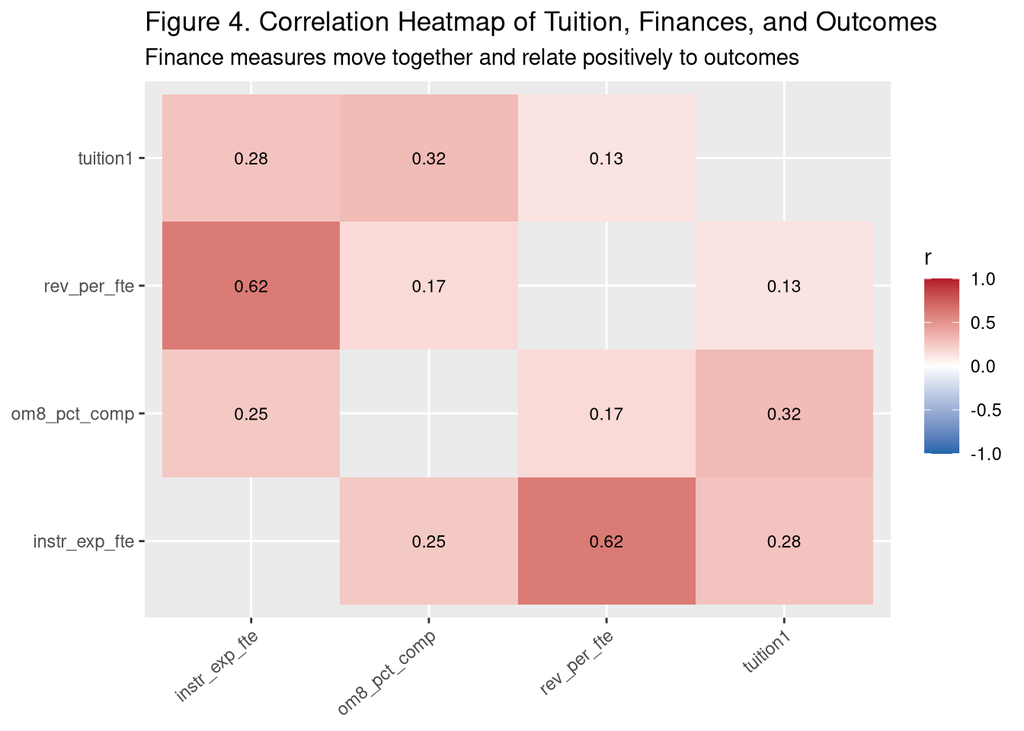

```r
#----figure-4--------------------------------------------------------------
#| label: fig-corr
#| fig-cap: "Correlation Heatmap of Tuition, Finances, and Outcomes"
vis_df |>
  select(tuition1, rev_per_fte, instr_exp_fte, om8_pct_comp) |>
  correlate(method = "pearson", use = "pairwise.complete.obs") |>
  stretch(na.rm = TRUE) |>
  ggplot(aes(x, y, fill = r)) +
  geom_tile() +
  geom_text(aes(label = sprintf("%.2f", r)), size = 3) +
  scale_fill_gradient2(
    low = "#2166AC", mid = "white", high = "#B2182B",
    limits = c(-1, 1), name = "r"
  ) +
  labs(
    title = "Figure 4. Correlation Heatmap of Tuition, Finances, and Outcomes",
    subtitle = "Finance measures move together and relate positively to outcomes",
    x = NULL, y = NULL
  ) +
  theme(axis.text.x = element_text(angle = 40, hjust = 1))
```

#### Figure 5. Student-to-Faculty Ratio by Sector

[figure not shown]

```r
#----figure-5--------------------------------------------------------------
pal_sector <- c(
  "Public"             = "#E15759",
  "Private Nonprofit"  = "#59A14F",
  "Private For-Profit" = "#4E79A7"
)

ipeds |>
  filter(!is.na(sector), !is.na(stufacr), stufacr > 0) |>
  mutate(stufacr_cap = pmin(stufacr, quantile(stufacr, 0.99, na.rm = TRUE))) |>
  ggplot(aes(y = sector, x = stufacr_cap, fill = sector)) +
  geom_boxplot(width = 0.5, outlier.alpha = 0.25, outlier.size = 0.9) +
  scale_fill_manual(values = pal_sector, guide = "none") +
  labs(
    title    = "Figure 5. Student-to-Faculty Ratio by Sector",
    subtitle = "Public institutions show tighter ratios; private institutions vary more widely",
    x        = "Student-to-faculty ratio",
    y        = NULL
  ) +
  theme(legend.position = "none")
```

#### Figure 6. Retention vs Completion by Sector

[figure not shown]

```r
#----figure-6--------------------------------------------------------------
ipeds |>
  filter(!is.na(sector), !is.na(retention_rate), !is.na(om8_pct_comp)) |>
  ggplot(aes(x = retention_rate, y = om8_pct_comp, color = sector)) +
  geom_point(alpha = 0.55, size = 2) +
  geom_smooth(method = "lm", se = FALSE, linetype = "dashed", color = "gray40") +
  scale_x_continuous(labels = label_percent(scale = 1)) +
  scale_y_continuous(labels = label_percent(scale = 1)) +
  labs(
    title = "Figure 6. Retention vs Completion by Sector",
    subtitle = "Higher retention rates align strongly with higher completion rates across all sectors",
    x = "First-year retention rate (%, full-time preferred; else part-time)",
    y = "Completion rate (8-year, %)",
    color = "Sector"
  )
```

## Modeling and Results

This section presents the analytical process and results of applying the K-Means clustering algorithm to institutional data from IPEDS. While the *Methods* section laid out the modeling framework and variable design, this section focuses on how the model was implemented, how the optimal number of clusters was chosen, and what structural patterns emerged across institutional segments.

### Data Preparation for Modeling

Prior to clustering, all selected quantitative features were standardized using z-score normalization to ensure comparability across scales. The final modeling dataset included institutions with valid and complete entries for key financial, access, and outcome metrics:

- `REV_PER_FTE`: revenue per full-time equivalent student
- `INSTR_EXP_FTE`: instructional expense per FTE
- `TUITION1`: in-state undergraduate tuition and fees
- `OM8_PCT_COMP`: 8-year student completion rate
- `RETENTION_RATE`: first-year retention (full-time preferred; part-time if missing)

### Determining the Optimal Number of Clusters

Selecting an appropriate number of clusters, (k), is a key decision in K-Means because it determines the level of segmentation and affects both interpretability and stability. To guide this choice, two internal validation techniques were applied:

1. **Elbow method (within-cluster sum of squares, WCSS)** — used to identify the point where adding more clusters yields diminishing improvements in compactness.
2. **Silhouette analysis** — used to evaluate how well each institution fits within its assigned cluster relative to neighboring clusters.

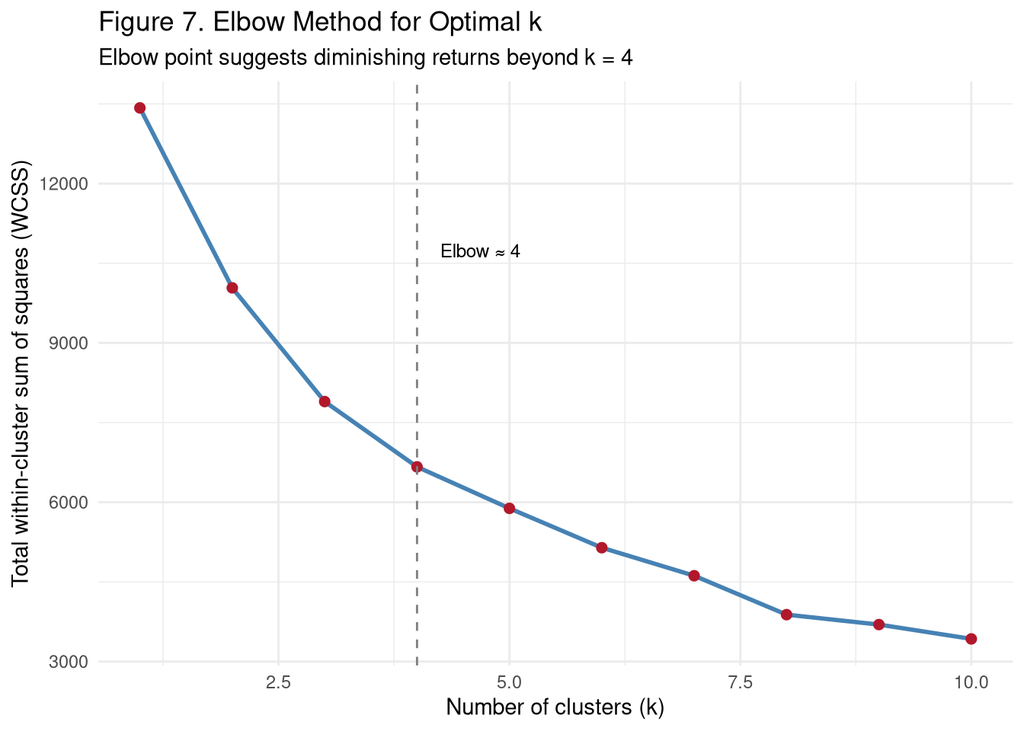

Elbow and Silhouette Analysis for Optimal k

```r
library(cluster)

# Prepare modeling matrix
X <- vis_df |>
  select(rev_per_fte, instr_exp_fte, tuition1, om8_pct_comp, retention_rate) |>
  drop_na() |>
  scale()

# --- Elbow ---------------------------------------------------------
set.seed(2024)
wcss <- map_dbl(1:10, ~ kmeans(X, centers = .x, nstart = 25)$tot.withinss)
elbow_df <- tibble(k = 1:10, wcss = wcss)

ggplot(elbow_df, aes(k, wcss)) +
  geom_line(color = "#4682B4", linewidth = 1) +
  geom_point(size = 2, color = "#B2182B") +
  geom_vline(xintercept = 4, linetype = "dashed", color = "gray50") +
  annotate("text", x = 4.25, y = max(wcss)*0.8, label = "Elbow ≈ 4", size = 3.2, hjust = 0) +
  labs(
    title = "Figure 7. Elbow Method for Optimal k",
    subtitle = "Elbow point suggests diminishing returns beyond k = 4",
    x = "Number of clusters (k)",
    y = "Total within-cluster sum of squares (WCSS)"
  ) +
  theme_minimal(base_size = 11)
```

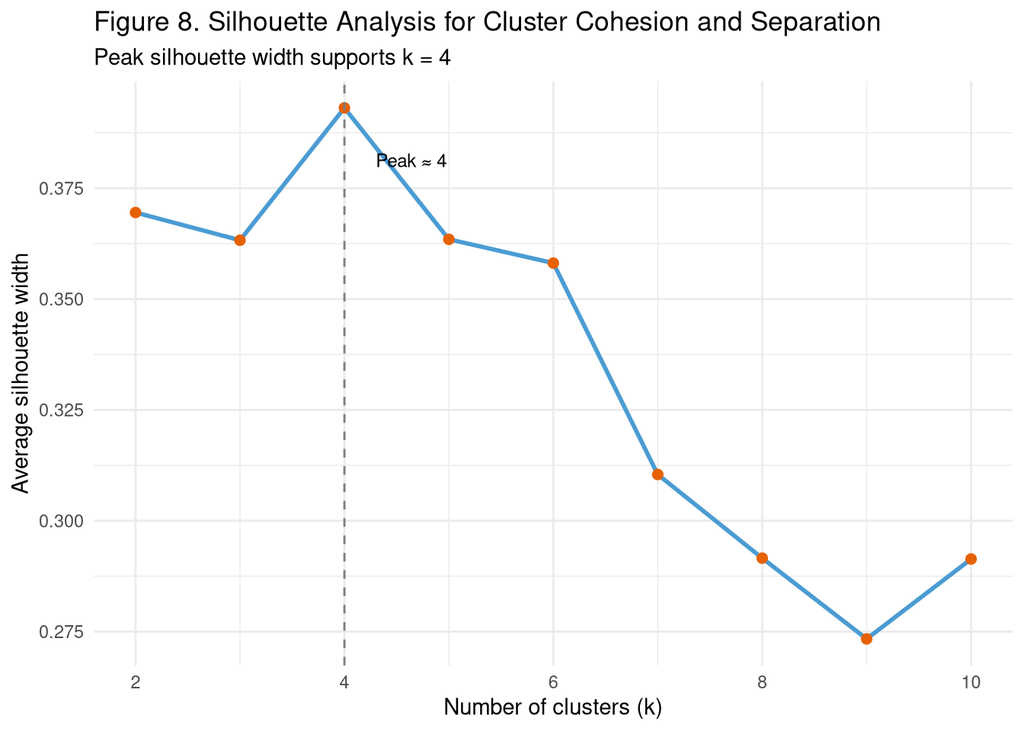

Elbow and Silhouette Analysis for Optimal k

```r
# --- Silhouette -----------------------------------------------------
silhouette_scores <- map_dbl(2:10, function(k) {
  km <- kmeans(X, centers = k, nstart = 25)
  ss <- silhouette(km$cluster, dist(X))
  mean(ss[, 3])
})

sil_df <- tibble(k = 2:10, silhouette = silhouette_scores)

ggplot(sil_df, aes(k, silhouette)) +
  geom_line(color = "#4B9CD3", linewidth = 1) +
  geom_point(size = 2, color = "#E66101") +
  geom_vline(xintercept = 4, linetype = "dashed", color = "gray50") +
  annotate("text", x = 4.3, y = max(silhouette_scores)*0.97, label = "Peak ≈ 4", size = 3.2, hjust = 0) +
  labs(
    title = "Figure 8. Silhouette Analysis for Cluster Cohesion and Separation",
    subtitle = "Peak silhouette width supports k = 4",
    x = "Number of clusters (k)",
    y = "Average silhouette width"
  ) +
  theme_minimal(base_size = 11)
```

### Final Clustering Model (k = 4)

```r
set.seed(2024)
final_k <- 4

model_df <- vis_df |>
  select(rev_per_fte, instr_exp_fte, tuition1, om8_pct_comp, retention_rate) |>
  drop_na()

X <- scale(model_df)
k_model <- kmeans(X, centers = final_k, nstart = 25)

ipeds_clustered <- model_df |>
  mutate(cluster = factor(k_model$cluster))

cluster_summary <- ipeds_clustered |>
  group_by(cluster) |>
  summarise(
    avg_tuition    = mean(tuition1,       na.rm = TRUE),
    avg_rev_fte    = mean(rev_per_fte,    na.rm = TRUE),
    avg_exp_fte    = mean(instr_exp_fte,  na.rm = TRUE),
    avg_completion = mean(om8_pct_comp,   na.rm = TRUE),
    avg_retention  = mean(retention_rate, na.rm = TRUE),
    n              = n()
  )

cluster_summary |>
  gt() |>
  fmt_currency(
    columns = c(avg_tuition, avg_rev_fte, avg_exp_fte),
    decimals = 0
  ) |>
  fmt_percent(
    columns = c(avg_completion, avg_retention),
    scale_values = FALSE,
    decimals = 1
  ) |>
  tab_header(
    title = "Table 1. Cluster-Level Summary Statistics",
    subtitle = "Average tuition, resources, and outcomes across institutional clusters"
  )
```

Table 1. Cluster-Level Summary Statistics

Average tuition, resources, and outcomes across institutional clusters

| cluster | avg_tuition | avg_rev_fte | avg_exp_fte | avg_completion | avg_retention | n |
| --- | --- | --- | --- | --- | --- | --- |
| 1 | $14,799 | $23,251 | $8,225 | 69.0% | 69.5% | 317 |
| 2 | $45,442 | $391,364 | $87,631 | 57.7% | 80.0% | 21 |
| 3 | $8,405 | $26,666 | $8,521 | 12.1% | 65.4% | 1637 |
| 4 | $40,947 | $43,034 | $15,758 | 32.1% | 81.1% | 711 |

K-Means Segmentation Results (k = 4)

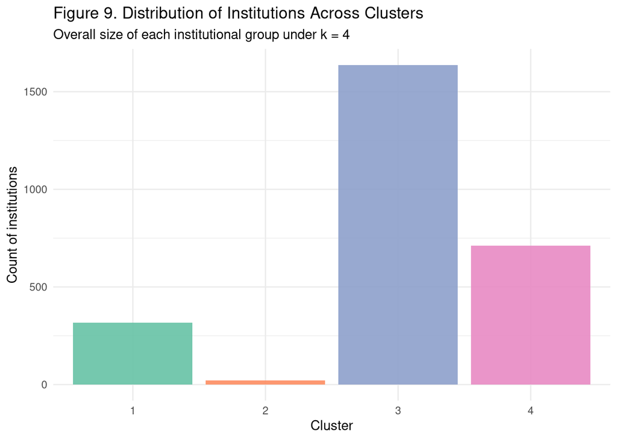

Figure 1: Distribution of Institutions Across Clusters (k = 4)

```r
ipeds_clustered |>
  ggplot(aes(x = cluster, fill = cluster)) +
  geom_bar(alpha = 0.9) +
  scale_fill_brewer(palette = "Set2") +
  labs(
    x = "Cluster",
    y = "Count of institutions",
    title = "Figure 9. Distribution of Institutions Across Clusters",
    subtitle = "Overall size of each institutional group under k = 4"
  ) +
  theme_minimal(base_size = 11) +
  theme(legend.position = "none")
```

#### Diagnostic Check: Variable Distributions by Cluster

[figure not shown]

### Visualizing Cluster Structure in Feature Space

To visualize how institutions separate in high-dimensional space, the standardized modeling matrix was projected into two components using Principal Component Analysis (PCA). PCA was not used for model fitting; instead, it provides a compact visualization that shows whether clusters form coherent regions. PC1 is primarily associated with overall resource intensity, and PC2 captures variation related to affordability and outcomes.

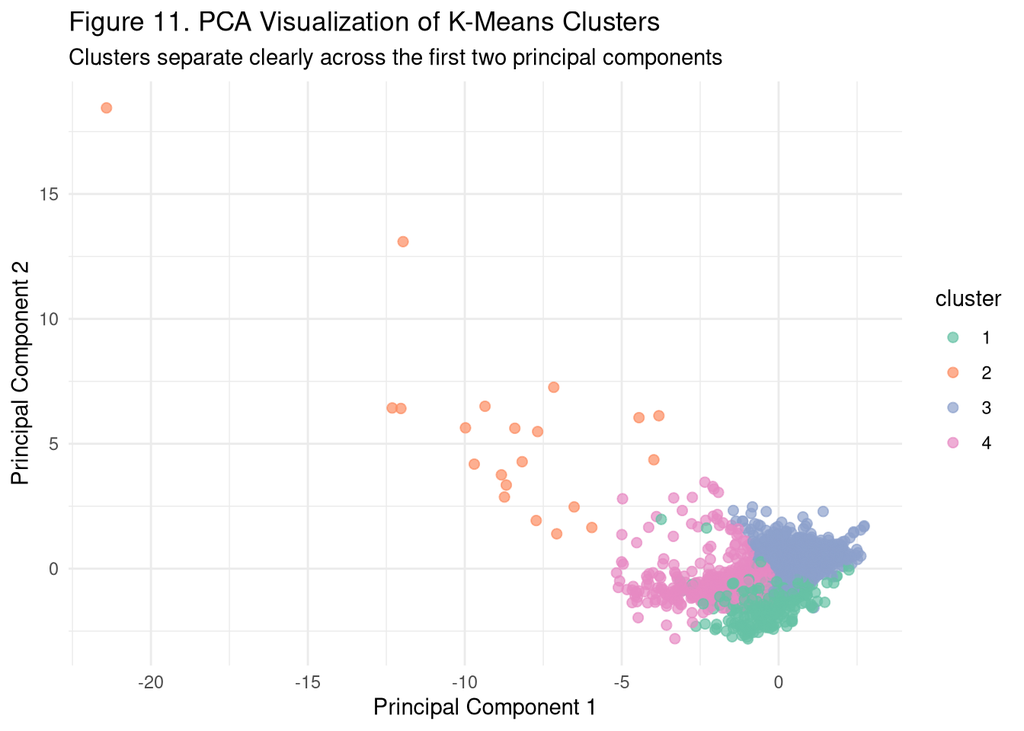

Figure 2: PCA Visualization of K-Means Clusters

```r
pca_res <- prcomp(X, scale. = FALSE)

pca_df <- as_tibble(pca_res$x[, 1:2]) |>
  mutate(cluster = ipeds_clustered$cluster)

ggplot(pca_df, aes(PC1, PC2, color = cluster)) +
  geom_point(alpha = 0.7, size = 2) +
  scale_color_brewer(palette = "Set2") +
  labs(
    title = "Figure 11. PCA Visualization of K-Means Clusters",
    subtitle = "Clusters separate clearly across the first two principal components",
    x = "Principal Component 1",
    y = "Principal Component 2"
  ) +
  theme_minimal(base_size = 11)
```

## Conclusion

Overall, the results show that a small, focused set of metrics is enough to reveal real structure in the higher education landscape. These segments can help with peer grouping, benchmarking, and conversations about funding and equity. Future work could bring in more variables, test other clustering approaches, or look at how student demographics and program mix change the picture. Even with the limited scope here, the model gives a clear and useful view of how institutions differ across the system.

## References

Elam, Jordan. 2016. “Proposal of a New Method to Classify Higher Education Institutions.” https://digitalcommons.otterbein.edu/cgi/viewcontent.cgi?article=1031&context=stu_dist.

Forgy, Edward W. 1965. “Cluster Analysis of Multivariate Data: Efficiency Versus Interpretability of Classifications.” *Biometrics* 21 (3): 768–69.

Huberty, Carl J., Ellen M. Jordan, and W. Charles Brandt. 2005. “Cluster Analysis in Higher Education Research.” In *Higher Education: Handbook of Theory and Research*, 20:437–57. Dordrecht: Springer. https://link.springer.com/content/pdf/10.1007/1-4020-3279-X_8.pdf.

Jain, Anil K. 2010. *Data Clustering: 50 Years Beyond k-Means*. *Pattern Recognition Letters*. Vol. 31. 8. Elsevier. https://doi.org/10.1016/j.patrec.2009.09.011.

Kelchen, Robert. 2019. “Merging Data to Facilitate Analyses.” Seton Hall University. https://robertkelchen.com/wp-content/uploads/2019/11/kelchen_merging_original.pdf.

Lloyd, Stuart P. 1982. “Least Squares Quantization in PCM.” *IEEE Transactions on Information Theory* 28 (2): 129–37. https://doi.org/10.1109/TIT.1982.1056489.

Mohd Talib, Nurul Izzati, Noor Azilah Abd Majid, and Shamala Sahran. 2023. “Identification of Student Behavioral Patterns in Higher Education Using k-Means Clustering and Support Vector Machine.” *Applied Sciences* 13 (5): 3267. https://doi.org/10.3390/app13053267.

National Center for Education Statistics. 2023. “Institutional Groupings in IPEDS: Considerations for Data Use.” https://nces.ed.gov/ipeds/use-the-data/institutional-groupings-in-ipeds.

Texas Association for Institutional Research. 2022. “A Hybrid Approach to Identifying National Peer Institutions.” https://www.texas-air.org/wp-content/uploads/2022/03/E3-A-Hybrid-Approach-to-Identifying-National-Peer-Institutions.pdf.